# pValues - Week 3

## Power

- Power is the probability of rejecting the null hypothesis when it is false
- Ergo, power (as its name would suggest) is a good thing; you want more power
- A type II error (a bad thing, as its name would suggest) is failing to reject the null hypothesis when it’s false; the probability of a type II error is usually called $\beta$
- Note Power $= 1 - \beta$

## Notes

- Consider our previous example involving RDI
- $H_0: \mu = 30$ versus $H_a: \mu > 30$
- Then power is
  $$P\left(\frac{\bar X - 30}{s /\sqrt{n}} > t_{1-\alpha,n-1} ~;~ \mu = \mu_a \right)$$
- Note that this is a function that depends on the specific value of $\mu_a$!
- Notice as $\mu_a$ approaches $30$ the power approaches $\alpha$

## Calculating power for Gaussian data

- We reject if $\frac{\bar X - 30}{\sigma /\sqrt{n}} > z_{1-\alpha}$
  - Equivalently if $\bar X > 30 + Z_{1-\alpha} \frac{\sigma}{\sqrt{n}}$
- Under $H_0 : \bar X \sim N(\mu_0, \sigma^2 / n)$
- Under $H_a : \bar X \sim N(\mu_a, \sigma^2 / n)$
- So we want

```r
alpha = 0.05
z = qnorm(1 - alpha)
pnorm(mu0 + z * sigma / sqrt(n), mean = mua, sd = sigma / sqrt(n),
      lower.tail = FALSE)
# upper.tail = false giver upper probability
# if mean = mu0, I get alpha.
# As mua moves away from alpha, power gets larger and larger
```

## Example continued

- $\mu_a = 32$, $\mu_0 = 30$, $n =16$, $\sigma = 4$

```r
mu0 = 30
mua = 32
sigma = 4
n = 16
alpha = 0.05
z = qnorm(1 - alpha)
pnorm(mu0 + z * sigma / sqrt(n), mean = mu0, sd = sigma / sqrt(n),
      lower.tail = FALSE)
```

```
## [1] 0.05
```

```r
pnorm(mu0 + z * sigma / sqrt(n), mean = mua, sd = sigma / sqrt(n),
      lower.tail = FALSE)
```

```
## [1] 0.63876
```

## Plotting the power curve

Power increases as $\mu_a$ gets larger. It means that we are more likely to detect a difference is the difference we want to detect is big. Which makes sense: if something has a huge effect, it should be very probably to detect.

As more data is collecte, it’s more likely to detect power for a specific value of $\mu_a$

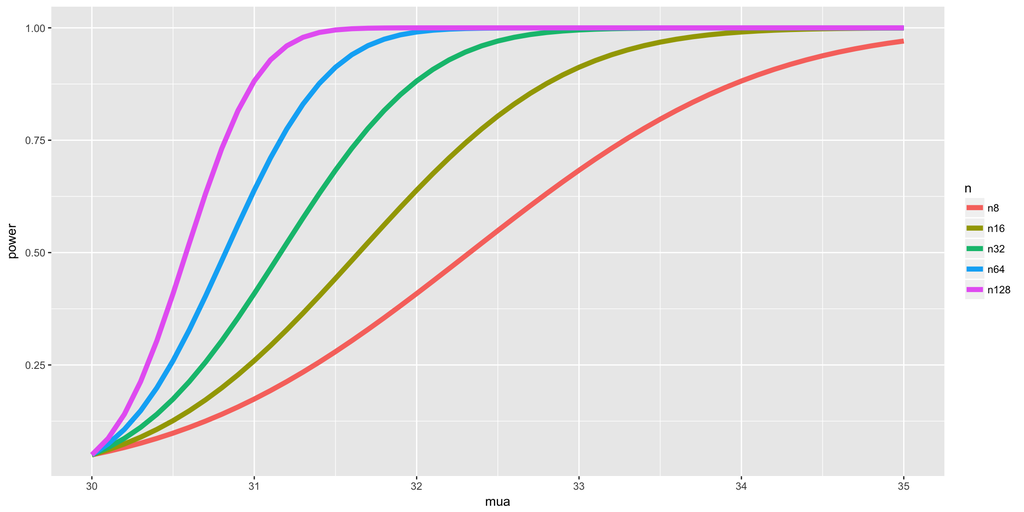

## Graphical Depiction of Power

The initial plots, before “manipulating” them says:

- under the H_0 (red), this is the distribution mean. It is centered at 30 and has a variance of sigma^2/n
- under the alternative hypothesis (blue line), it is centered at 32 and it has a variance of sigma^2/n
- black vertical line is the critical value. It has been set so that if we get a sample mean that is larger than the threshold, the H_0 is rejected.
- power is the probability pf rejecting if in fact the blue curve is true.

```r
mu0 = 30
myplot <- function(sigma, mua, n, alpha){
    g = ggplot(data.frame(mu = c(27, 36)), aes(x = mu))
    g = g + stat_function(fun=dnorm, geom = "line",
                          args = list(mean = mu0, sd = sigma / sqrt(n)),
                          size = 2, col = "red")
    g = g + stat_function(fun=dnorm, geom = "line",
                          args = list(mean = mua, sd = sigma / sqrt(n)),
                          size = 2, col = "blue")
    xitc = mu0 + qnorm(1 - alpha) * sigma / sqrt(n)
    g = g + geom_vline(xintercept=xitc, size = 3)
    g
}
manipulate(
    myplot(sigma, mua, n, alpha),
    sigma = slider(1, 10, step = 1, initial = 4),
    mua = slider(30, 35, step = 1, initial = 32),
    n = slider(1, 50, step = 1, initial = 16),
    alpha = slider(0.01, 0.1, step = 0.01, initial = 0.05)
    )
```

[output not shown]

## Question

- When testing $H_a : \mu > \mu_0$, notice if power is $1 - \beta$, then
  $$1 - \beta = P\left(\bar X > \mu_0 + z_{1-\alpha} \frac{\sigma}{\sqrt{n}} ; \mu = \mu_a \right)$$
- where $\bar X \sim N(\mu_a, \sigma^2 / n)$
- Unknowns: $\mu_a$, $\sigma$, $n$, $\beta$
- Knowns: $\mu_0$, $\alpha$
- Specify any 3 of the unknowns and you can solve for the remainder

## Notes

- The calculation for $H_a:\mu < \mu_0$ is similar
- For $H_a: \mu \neq \mu_0$ calculate the one sided power using $\alpha / 2$ (this is only approximately right, it excludes the probability of getting a large TS in the opposite direction of the truth)
- Power goes up as $\alpha$ gets larger
- Power of a one sided test is greater than the power of the associated two sided test: as $\alpha /2$
- Power goes up as $\mu_1$ gets further away from $\mu_0$
- Power goes up as $n$ goes up
- Power doesn’t need $\mu_a$, $\sigma$ and $n$, instead only $\frac{\sqrt{n}(\mu_a - \mu_0)}{\sigma}$
  - The quantity $\frac{\mu_a - \mu_0}{\sigma}$ is called the **effect size**, the difference in the means in standard deviation units.
  - Being unit free, it has some hope of interpretability across settings

## T-test power

- Consider calculating power for a Gossett’s $T$ test for our example
- The power is
  $$P\left(\frac{\bar X - \mu_0}{S /\sqrt{n}} > t_{1-\alpha, n-1} ~;~ \mu = \mu_a \right)$$
- Calcuting this requires the non-central t distribution.
- `power.t.test` does this very well
- Omit one of the arguments and it solves for it

## Example

```r
power.t.test(n = 16, delta = 2 / 4, sd=1, type = "one.sample",  alt = "one.sided")$power
```

```
## [1] 0.6040329
```

```r
# H_0: mu = mu0 X H_a:mu > mu0 (one sided)
# delta is the difference in the means
# power only deppends on the effect size: (mua - mu0) / sd
power.t.test(n = 16, delta = 2, sd=4, type = "one.sample",  alt = "one.sided")$power
```

```
## [1] 0.6040329
```

```r
power.t.test(n = 16, delta = 100, sd=200, type = "one.sample", alt = "one.sided")$power
```

```
## [1] 0.6040329
```

## Example

```r
power.t.test(power = .8, delta = 2 / 4, sd=1, type = "one.sample",  alt = "one.sided")$n
```

```
## [1] 26.13751
```

```r
power.t.test(power = .8, delta = 2, sd=4, type = "one.sample",  alt = "one.sided")$n
```

```
## [1] 26.13751
```

```r
power.t.test(power = .8, delta = 100, sd=200, type = "one.sample", alt = "one.sided")$n
```

```
## [1] 26.13751
```

## Exercises

1. Power is a probability calculation assuming which is true:

The null hypothesis

`The alternative hypothesis`

Both the null and alternative

#### Explanation:

https://onlinecourses.science.psu.edu/stat414/book/export/html/245

2. As your sample size gets bigger, all else equal, what do you think would happen to power?

`It would get larger`

It would get smaller

It would stay the same

It cannot be determined from the information given

3. What happens to power as $\mu_a$ gets further from $\mu_0$?

Power decreases

`Power increases`

Power stays the same

Power oscillates

4. In the context of calculating power, the effect size is?

The null mean divided by the standard deviation

The alternative mean divided by the standard error

`The difference between the null and alternative means divided by the standard deviation`

The standard error divided by the null mean

5. Recall this problem “Suppose that in an AB test, one advertising scheme led to an average of 10 purchases per day for a sample of 100 days, while the other led to 11 purchases per day, also for a sample of 100 days. Assuming a common standard deviation of 4 purchases per day.” Assuming that 10 purchases per day is a benchmark null value, that days are iid and that the standard deviation is 4 purchases for day. Suppose that you plan on sampling 100 days. What would be the power for a one sided 5% Z mean test that purchases per day have increased under the alternative of $\mu = 11$ purchase per day?

```r
# H0: mu = 10
# Ha: mu > 10
n = 100
s = 0.4

# under the null hypothesis
# m ~ N(10, 4/sqrt(100))
# reject if m > 10 + 1.645 *  0.4

# under Ha
# m ~ N(11, 0.4)

pnorm(10.658, mean = 11, sd = 0.4, lower.tail = FALSE)
```

```
## [1] 0.8037244
```

6. Researchers would like to conduct a study of healthy adults to detect a four year mean brain volume loss of .01 $mm^3$. Assume that the standard deviation of four year volume loss in this population is .04 $mm3$. What is necessary sample size for the study for a 5% one sided test versus a null hypothesis of no volume loss to achieve 80% power?

```r
# H0: mu = 0
# Ha: mu > 0
#sd = 0.04
#power = 0.8
#mua = 0.01

# under the null hypothesis
# m ~ N(0, 0.04/sqrt(n))
# reject if m > 0 + 1.645 *  (0.04/sqrt(n))
# or
# reject if m > 0 + qnorm(0.05, lower.tail = FALSE) *  (0.04/sqrt(n))

# under Ha
# m ~ N(0.01, 0.04/sqrt(n))
#
# would try with different values of n until pnorm is equals to 80%
n=c(97, 98, 99, 100)
pnorm((1.645 * 0.04)/sqrt(n), mean = 0.01, sd = 0.04/sqrt(n), lower.tail = FALSE)
```

```
## [1] 0.7930971 0.7966949 0.8002371 0.8037244
```